# Codebook example with manual labelling

Ruben Arslan

2018-08-01

In this vignette, you can see how to add metadata to a dataset when it isn’t already stored in its attributes. For this example, we’ll use the `bfi` and `bfi.dictionary` datasets from the `psych` package. We use functions from the `labelled` package to set the relevant attributes with convenience functions.

```r
knit_by_pkgdown <- !is.null(knitr::opts_chunk$get("fig.retina"))
library(dplyr)
library(codebook)
library(labelled)
pander::panderOptions("table.split.table", Inf)
ggplot2::theme_set(ggplot2::theme_bw())

data("bfi", package = 'psych')
bfi <- bfi %>% tbl_df()
data("bfi.dictionary", package = 'psych')
bfi.dictionary$variable = rownames(bfi.dictionary)
bfi.dictionary <- bfi.dictionary %>% tbl_df()
```

Let’s start by getting an overview of our dataset

```r
head(bfi, 20)
```

```
## # A tibble: 20 x 28
##       A1    A2    A3    A4    A5    C1    C2    C3    C4    C5    E1    E2
##    <int> <int> <int> <int> <int> <int> <int> <int> <int> <int> <int> <int>
##  1     2     4     3     4     4     2     3     3     4     4     3     3
##  2     2     4     5     2     5     5     4     4     3     4     1     1
##  3     5     4     5     4     4     4     5     4     2     5     2     4
##  4     4     4     6     5     5     4     4     3     5     5     5     3
##  5     2     3     3     4     5     4     4     5     3     2     2     2
##  6     6     6     5     6     5     6     6     6     1     3     2     1
##  7     2     5     5     3     5     5     4     4     2     3     4     3
##  8     4     3     1     5     1     3     2     4     2     4     3     6
##  9     4     3     6     3     3     6     6     3     4     5     5     3
## 10     2     5     6     6     5     6     5     6     2     1     2     2
## 11     4     4     5     6     5     4     3     5     3     2     1     3
## 12     2     5     5     5     5     5     4     5     4     5     3     3
## 13     5     5     5     6     4     5     4     3     2     2     3     3
## 14     5     5     5     6     6     4     4     4     2     1     2     2
## 15     4     5     2     2     1     5     5     5     2     2     3     4
## 16     4     3     6     6     3     5     5     5     3     5     1     1
## 17     4     6     6     2     5     4     4     4     4     4     1     2
## 18     5     5     5     4     5     5     5     5     4     3     2     2
## 19     4     4     5     4     3     5     4     5     4     6     1     2
## 20     4     4     6     5     5     1     1     1     5     6     1     1
## # ... with 16 more variables: E3 <int>, E4 <int>, E5 <int>, N1 <int>,
## #   N2 <int>, N3 <int>, N4 <int>, N5 <int>, O1 <int>, O2 <int>, O3 <int>,
## #   O4 <int>, O5 <int>, gender <int>, education <int>, age <int>
```

and our data dictionary.

```r
bfi.dictionary
```

```
## # A tibble: 28 x 8
##    ItemLabel Item         Giant3 Big6    Little12  Keying IPIP100 variable
##  * <fct>     <fct>        <fct>  <fct>   <fct>      <int> <fct>   <chr>
##  1 q_146     Am indiffer… Cohes… Agreea… Compassi…     -1 B5:A    A1
##  2 q_1162    Inquire abo… Cohes… Agreea… Compassi…      1 B5:A    A2
##  3 q_1206    Know how to… Cohes… Agreea… Compassi…      1 B5:A    A3
##  4 q_1364    Love childr… Cohes… Agreea… Compassi…      1 B5:A    A4
##  5 q_1419    Make people… Cohes… Agreea… Compassi…      1 B5:A    A5
##  6 q_124     Am exacting… Stabi… Consci… Orderlin…      1 B5:C    C1
##  7 q_530     Continue un… Stabi… Consci… Orderlin…      1 B5:C    C2
##  8 q_619     Do things a… Stabi… Consci… Orderlin…      1 B5:C    C3
##  9 q_626     Do things i… Stabi… Consci… Industri…     -1 B5:C    C4
## 10 q_1949    Waste my ti… Stabi… Consci… Industri…     -1 B5:C    C5
## # ... with 18 more rows
```

## How to add variable and value labels

Using the `var_label` function from the `labelled` package, we can easily assign a label to a variable (or a list of labels to a dataset).

```r
# First, let's see what we know about these variables.
bfi <- bfi %>% # here we use the pipe (feeding the bfi argument into the pipe)
  mutate(education = as.double(education), # the labelled class is a bit picky and doesn't like integers
         gender = as.double(gender))

bfi.dictionary %>% tail(3)
```

```
## # A tibble: 3 x 8
##   ItemLabel Item             Giant3 Big6  Little12 Keying IPIP100 variable
##   <fct>     <fct>            <fct>  <fct> <fct>     <int> <fct>   <chr>
## 1 gender    males=1, female… <NA>   <NA>  <NA>         NA <NA>    gender
## 2 education in HS, fin HS, … <NA>   <NA>  <NA>         NA <NA>    educati…
## 3 age       age in years     <NA>   <NA>  <NA>         NA <NA>    age
```

```r
var_label(bfi$gender) <- "Self-reported gender"
attributes(bfi$gender) # check what we're doing
```

```
## $label
## [1] "Self-reported gender"
```

```r
var_label(bfi) <- list(age = "age in years", education = "Highest degree")

# or using dplyr syntax
bfi <- bfi %>% set_variable_labels(
  age = "age in years",
  education = "Highest degree")
```

Now, we saw that the value labels were encoded in the variable label. This is not what we want. Instead, we assign value labels.

```r
bfi <- bfi %>%
  add_value_labels(
    gender = c("male" = 1, "female" = 2),
    education = c("in high school" = 1, "finished high school" = 2,
                  "some college" = 3, "college graduate" = 4,
                  "graduate degree" = 5) # dont use abbreviations if you can avoid it
    )
attributes(bfi$gender) # check what we're doing
```

```
## $label
## [1] "Self-reported gender"
##
## $labels
##   male female
##      1      2
##
## $class
## [1] "labelled"
```

```r
# We could also assign the attributes manually, but then there's no error checking.
attributes(bfi$gender) <- list(
  label = "Self-reported gender",
  labels = c(male = 1L, female = 2L),
  class = "labelled")
```

As we see, adding value labels turned the variable `gender` into a different type (from a simple integer to a labelled class).

This is all pretty tedious, and we have the data we need in a nice dictionary already. With a few easy steps, we can transform it.

```r
dict <- bfi.dictionary %>%
  filter(! variable %in% c("gender", "education", "age")) %>% # we did those already
  mutate(label = paste0(Big6, ": ", Item)) %>% # make sure we name the construct in the label
  select(variable, label, Keying)

# turn the key-value data frame into  a list
labels <- dict$label %>% as.character() %>% as.list() %>%
  purrr::set_names(dict$variable)

# assign the list of labels to the bfi data frame
var_label(bfi) <- labels

# assign value labels to all likert items
value_labels <- c("Very Inaccurate" = 1,
                  "Moderately Inaccurate" = 2,
                  "Slightly Inaccurate" = 3,
                  "Slightly Accurate" = 4,
                  "Moderately Accurate" = 5,
                  "Very Accurate" = 6)

add_likert_label <- function(x) {
  val_labels(x) <- value_labels
  x
}

bfi <- bfi %>%
  mutate_at(dict %>% pull(variable),
                         add_likert_label)

# reverse underlying values for the reverse-keyed items
bfi <- bfi %>%
  mutate_at(dict %>% filter(Keying == -1) %>% pull(variable),
    reverse_labelled_values) %>%
  rename_at(dict %>% filter(Keying == -1) %>% pull(variable),
    ~ paste0(.,"R"))

attributes(bfi$A1R)
```

```
## $label
## [1] "Agreeableness: Am indifferent to the feelings of others."
##
## $labels
##       Very Inaccurate Moderately Inaccurate   Slightly Inaccurate
##                     6                     5                     4
##     Slightly Accurate   Moderately Accurate         Very Accurate
##                     3                     2                     1
##
## $class
## [1] "labelled"
```

## Aggregating scales

Now, we can form scale aggregates. The `codebook` function `aggregate_and_document_scale` does this for us and automatically sets the correct attributes.

```r
bfi$consc <- aggregate_and_document_scale(bfi %>% select(starts_with("C")))
bfi$extra <- aggregate_and_document_scale(bfi %>% select(starts_with("E", ignore.case = F)))
bfi$open <- aggregate_and_document_scale(bfi %>% select(starts_with("O")))
bfi$agree <- aggregate_and_document_scale(bfi %>% select(starts_with("A", ignore.case = F)))
bfi$neuro <- aggregate_and_document_scale(bfi %>% select(starts_with("N")))
```

```r
knitr::opts_chunk$set(warning = TRUE, message = TRUE, error = TRUE, echo = FALSE)
```

Finally, we can generate our codebook.

## Items

### gender

Self-reported gender

#### Distribution

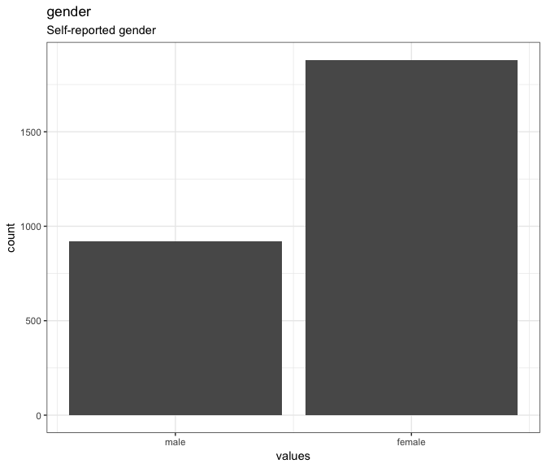

0 missings.

#### Summary statistics

| name | label | data_type | value_labels | missing | complete | n | mean | sd | p0 | p25 | p50 | p75 | p100 | hist |
| --- | --- | --- | --- | --- | --- | --- | --- | --- | --- | --- | --- | --- | --- | --- |
| gender | Self-reported gender | numeric | 1. male, 2. female | 0 | 2800 | 2800 | 1.67 | 0.47 | 1 | 1 | 2 | 2 | 2 | ▃▁▁▁▁▁▁▇ |

#### Value labels

- **male**: *1*
- **female**: *2*

### education

Highest degree

#### Distribution

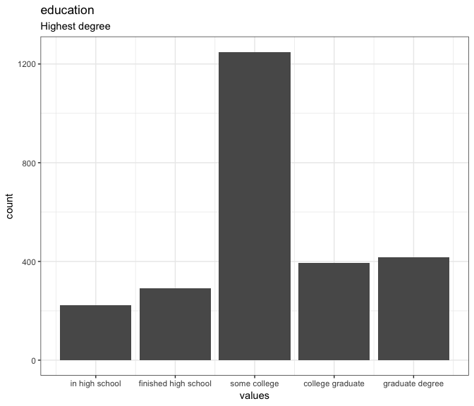

223 missings.

#### Summary statistics

| name | label | data_type | value_labels | missing | complete | n | mean | sd | p0 | p25 | p50 | p75 | p100 | hist |
| --- | --- | --- | --- | --- | --- | --- | --- | --- | --- | --- | --- | --- | --- | --- |
| education | Highest degree | numeric | 1. in high school, 2. finished high school, 3. some college, 4. college graduate, 5. graduate degree | 223 | 2577 | 2800 | 3.19 | 1.11 | 1 | 3 | 3 | 4 | 5 | ▂▂▁▇▁▂▁▃ |

#### Value labels

- **in high school**: *1*
- **finished high school**: *2*
- **some college**: *3*
- **college graduate**: *4*
- **graduate degree**: *5*

### age

age in years

#### Distribution

```
## Error: `x` must be a double vector
```

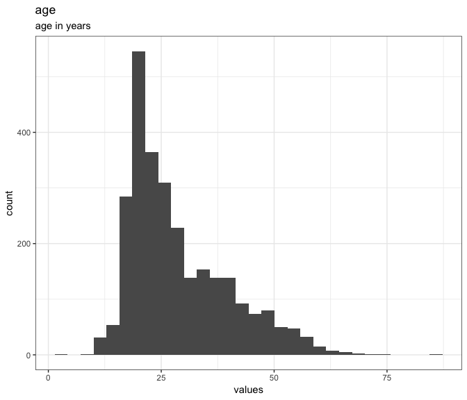

0 missings.

#### Summary statistics

| name | label | data_type | missing | complete | n | mean | sd | p0 | p25 | p50 | p75 | p100 | hist |
| --- | --- | --- | --- | --- | --- | --- | --- | --- | --- | --- | --- | --- | --- |
| age | age in years | integer | 0 | 2800 | 2800 | 28.78 | 11.13 | 3 | 20 | 26 | 35 | 86 | ▁▇▆▃▂▁▁▁ |

### Scale: consc

#### Overview

**Reliability**: Cronbach’s α [95% CI] = 0.73 [0.71;0.74].

**Missings**: 93.

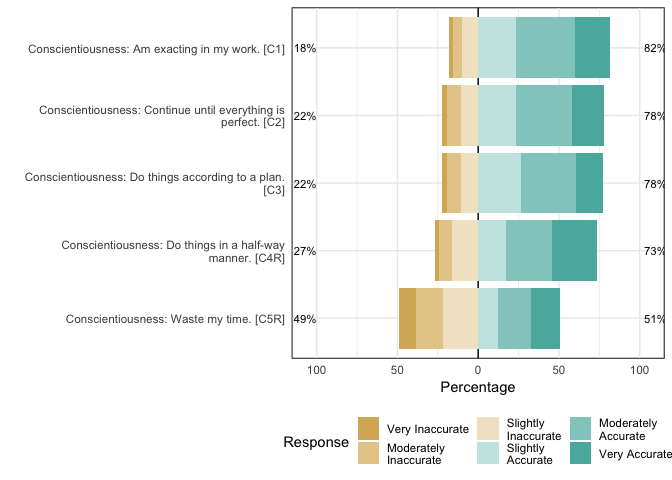

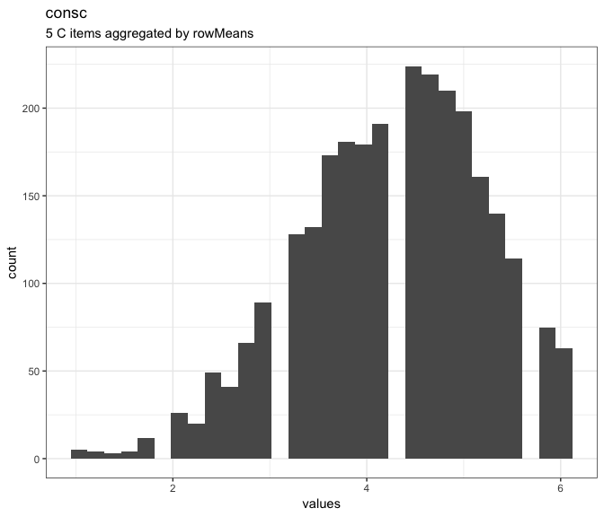

#### Reliability details

##### Reliability

##### 95% Confidence Interval

| lower | estimate | upper |
| --- | --- | --- |
| 0.7108 | 0.7267 | 0.7426 |

| raw_alpha | std.alpha | G6(smc) | average_r | S/N | ase | mean | sd | median_r |
| --- | --- | --- | --- | --- | --- | --- | --- | --- |
| 0.7267 | 0.7301 | 0.6942 | 0.351 | 2.705 | 0.008117 | 4.266 | 0.9513 | 0.34 |

##### Reliability if an item is dropped:

|  | raw_alpha | std.alpha | G6(smc) | average_r | S/N | alpha se | var.r | med.r |
| --- | --- | --- | --- | --- | --- | --- | --- | --- |
| **C1** | 0.694 | 0.6964 | 0.6401 | 0.3645 | 2.294 | 0.009337 | 0.003733 | 0.3478 |
| **C2** | 0.6736 | 0.6749 | 0.6189 | 0.3416 | 2.076 | 0.009891 | 0.005605 | 0.3383 |
| **C3** | 0.6887 | 0.694 | 0.6443 | 0.3618 | 2.268 | 0.009564 | 0.007021 | 0.3597 |
| **C4R** | 0.6538 | 0.6629 | 0.6028 | 0.3296 | 1.967 | 0.01066 | 0.003672 | 0.3237 |
| **C5R** | 0.6897 | 0.6902 | 0.6283 | 0.3577 | 2.228 | 0.009562 | 0.001734 | 0.3476 |

##### Item statistics

|  | n | raw.r | std.r | r.cor | r.drop | mean | sd |
| --- | --- | --- | --- | --- | --- | --- | --- |
| **C1** | 2779 | 0.6457 | 0.6702 | 0.5399 | 0.4502 | 4.502 | 1.241 |
| **C2** | 2776 | 0.6964 | 0.7097 | 0.6027 | 0.5046 | 4.37 | 1.318 |
| **C3** | 2780 | 0.6639 | 0.6748 | 0.5389 | 0.4642 | 4.304 | 1.289 |
| **C4R** | 2774 | 0.7365 | 0.7306 | 0.6413 | 0.5525 | 4.447 | 1.375 |
| **C5R** | 2784 | 0.7197 | 0.6819 | 0.566 | 0.4775 | 3.703 | 1.629 |

##### Non missing response frequency for each item

|  | 1 | 2 | 3 | 4 | 5 | 6 | miss |
| --- | --- | --- | --- | --- | --- | --- | --- |
| **C1** | 0.02627 | 0.05793 | 0.09896 | 0.2357 | 0.3663 | 0.2148 | 0.0075 |
| **C2** | 0.03206 | 0.08501 | 0.1066 | 0.2316 | 0.3465 | 0.1981 | 0.008571 |
| **C3** | 0.03022 | 0.08921 | 0.1054 | 0.2665 | 0.3388 | 0.1698 | 0.007143 |
| **C4R** | 0.02271 | 0.08219 | 0.1615 | 0.1702 | 0.2862 | 0.2772 | 0.009286 |
| **C5R** | 0.1024 | 0.1674 | 0.2205 | 0.125 | 0.2037 | 0.181 | 0.005714 |

#### Summary statistics

| name | label | data_type | value_labels | missing | complete | n | mean | sd | p0 | p25 | p50 | p75 | p100 | hist |
| --- | --- | --- | --- | --- | --- | --- | --- | --- | --- | --- | --- | --- | --- | --- |
| C1 | Conscientiousness: Am exacting in my work. | integer | 1. Very Inaccurate, 2. Moderately Inaccurate, 3. Slightly Inaccurate, 4. Slightly Accurate, 5. Moderately Accurate, 6. Very Accurate | 21 | 2779 | 2800 | 4.5 | 1.24 | 1 | 4 | 5 | 5 | 6 | ▁▁▁▂▅▁▇▅ |
| C2 | Conscientiousness: Continue until everything is perfect. | integer | 1. Very Inaccurate, 2. Moderately Inaccurate, 3. Slightly Inaccurate, 4. Slightly Accurate, 5. Moderately Accurate, 6. Very Accurate | 24 | 2776 | 2800 | 4.37 | 1.32 | 1 | 4 | 5 | 5 | 6 | ▁▂▁▂▆▁▇▅ |
| C3 | Conscientiousness: Do things according to a plan. | integer | 1. Very Inaccurate, 2. Moderately Inaccurate, 3. Slightly Inaccurate, 4. Slightly Accurate, 5. Moderately Accurate, 6. Very Accurate | 20 | 2780 | 2800 | 4.3 | 1.29 | 1 | 4 | 5 | 5 | 6 | ▁▂▁▂▆▁▇▅ |
| C4R | Conscientiousness: Do things in a half-way manner. | numeric | 6. Very Inaccurate, 5. Moderately Inaccurate, 4. Slightly Inaccurate, 3. Slightly Accurate, 2. Moderately Accurate, 1. Very Accurate | 26 | 2774 | 2800 | 4.45 | 1.38 | 1 | 3 | 5 | 6 | 6 | ▁▂▁▅▅▁▇▇ |
| C5R | Conscientiousness: Waste my time. | numeric | 6. Very Inaccurate, 5. Moderately Inaccurate, 4. Slightly Inaccurate, 3. Slightly Accurate, 2. Moderately Accurate, 1. Very Accurate | 16 | 2784 | 2800 | 3.7 | 1.63 | 1 | 2 | 4 | 5 | 6 | ▃▆▁▇▅▁▇▆ |

### Scale: extra

#### Overview

**Reliability**: Cronbach’s α [95% CI] = 0.76 [0.75;0.78].

**Missings**: 87.

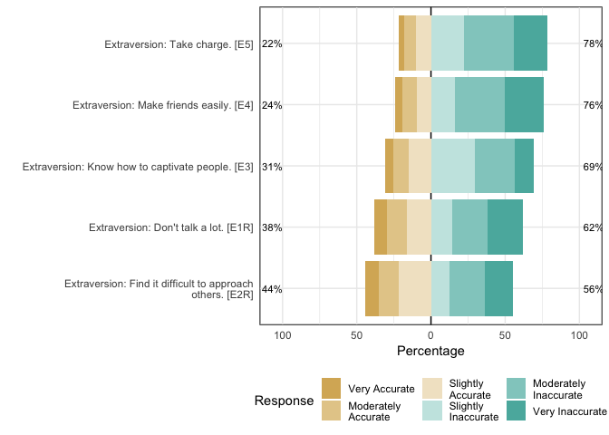

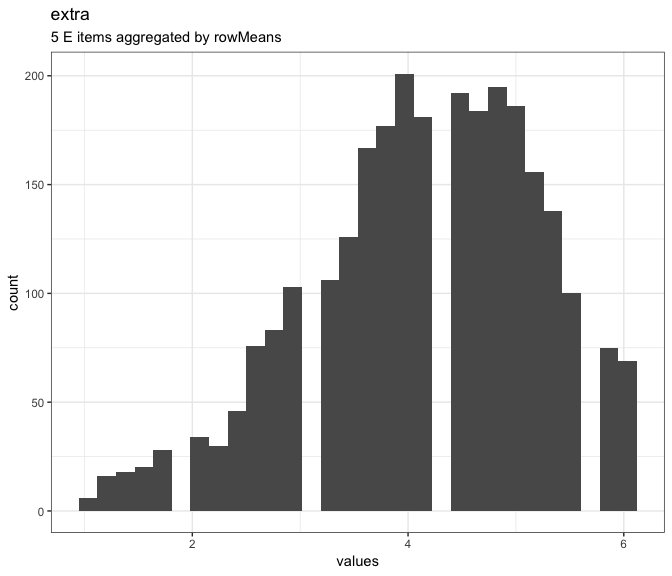

#### Reliability details

##### Reliability

##### 95% Confidence Interval

| lower | estimate | upper |
| --- | --- | --- |
| 0.748 | 0.7617 | 0.7755 |

| raw_alpha | std.alpha | G6(smc) | average_r | S/N | ase | mean | sd | median_r |
| --- | --- | --- | --- | --- | --- | --- | --- | --- |
| 0.7617 | 0.7618 | 0.7266 | 0.3901 | 3.198 | 0.007027 | 4.145 | 1.061 | 0.3818 |

##### Reliability if an item is dropped:

|  | raw_alpha | std.alpha | G6(smc) | average_r | S/N | alpha se | var.r | med.r |
| --- | --- | --- | --- | --- | --- | --- | --- | --- |
| **E1R** | 0.7257 | 0.7254 | 0.6731 | 0.3978 | 2.642 | 0.00837 | 0.004394 | 0.3818 |
| **E2R** | 0.6902 | 0.6931 | 0.6342 | 0.3608 | 2.258 | 0.009509 | 0.002792 | 0.3546 |
| **E3** | 0.7279 | 0.7262 | 0.6737 | 0.3988 | 2.653 | 0.008241 | 0.007098 | 0.396 |
| **E4** | 0.7019 | 0.7032 | 0.6464 | 0.372 | 2.37 | 0.009073 | 0.003275 | 0.3767 |
| **E5** | 0.7436 | 0.7442 | 0.6914 | 0.4211 | 2.909 | 0.007824 | 0.004344 | 0.419 |

##### Item statistics

|  | n | raw.r | std.r | r.cor | r.drop | mean | sd |
| --- | --- | --- | --- | --- | --- | --- | --- |
| **E1R** | 2777 | 0.7238 | 0.7027 | 0.5882 | 0.5163 | 4.026 | 1.632 |
| **E2R** | 2784 | 0.7797 | 0.7647 | 0.6936 | 0.6054 | 3.858 | 1.605 |
| **E3** | 2775 | 0.683 | 0.7011 | 0.5827 | 0.5046 | 4.001 | 1.353 |
| **E4** | 2791 | 0.7467 | 0.7459 | 0.6625 | 0.578 | 4.422 | 1.458 |
| **E5** | 2779 | 0.6432 | 0.6637 | 0.5229 | 0.4542 | 4.416 | 1.335 |

##### Non missing response frequency for each item

|  | 1 | 2 | 3 | 4 | 5 | 6 | miss |
| --- | --- | --- | --- | --- | --- | --- | --- |
| **E1R** | 0.08678 | 0.1322 | 0.162 | 0.1455 | 0.2348 | 0.2387 | 0.008214 |
| **E2R** | 0.09124 | 0.1383 | 0.2152 | 0.1232 | 0.2407 | 0.1915 | 0.005714 |
| **E3** | 0.05369 | 0.1056 | 0.1485 | 0.2977 | 0.2677 | 0.1268 | 0.008929 |
| **E4** | 0.05016 | 0.09387 | 0.0971 | 0.1612 | 0.3375 | 0.2601 | 0.003214 |
| **E5** | 0.03418 | 0.07953 | 0.1036 | 0.2227 | 0.3383 | 0.2217 | 0.0075 |

#### Summary statistics

| name | label | data_type | value_labels | missing | complete | n | mean | sd | p0 | p25 | p50 | p75 | p100 | hist |
| --- | --- | --- | --- | --- | --- | --- | --- | --- | --- | --- | --- | --- | --- | --- |
| E1R | Extraversion: Don’t talk a lot. | numeric | 6. Very Inaccurate, 5. Moderately Inaccurate, 4. Slightly Inaccurate, 3. Slightly Accurate, 2. Moderately Accurate, 1. Very Accurate | 23 | 2777 | 2800 | 4.03 | 1.63 | 1 | 3 | 4 | 5 | 6 | ▃▅▁▆▅▁▇▇ |
| E2R | Extraversion: Find it difficult to approach others. | numeric | 6. Very Inaccurate, 5. Moderately Inaccurate, 4. Slightly Inaccurate, 3. Slightly Accurate, 2. Moderately Accurate, 1. Very Accurate | 16 | 2784 | 2800 | 3.86 | 1.61 | 1 | 3 | 4 | 5 | 6 | ▃▅▁▇▅▁▇▆ |
| E3 | Extraversion: Know how to captivate people. | integer | 1. Very Inaccurate, 2. Moderately Inaccurate, 3. Slightly Inaccurate, 4. Slightly Accurate, 5. Moderately Accurate, 6. Very Accurate | 25 | 2775 | 2800 | 4 | 1.35 | 1 | 3 | 4 | 5 | 6 | ▂▃▁▃▇▁▇▃ |
| E4 | Extraversion: Make friends easily. | integer | 1. Very Inaccurate, 2. Moderately Inaccurate, 3. Slightly Inaccurate, 4. Slightly Accurate, 5. Moderately Accurate, 6. Very Accurate | 9 | 2791 | 2800 | 4.42 | 1.46 | 1 | 4 | 5 | 6 | 6 | ▁▂▁▂▃▁▇▆ |
| E5 | Extraversion: Take charge. | integer | 1. Very Inaccurate, 2. Moderately Inaccurate, 3. Slightly Inaccurate, 4. Slightly Accurate, 5. Moderately Accurate, 6. Very Accurate | 21 | 2779 | 2800 | 4.42 | 1.33 | 1 | 4 | 5 | 5 | 6 | ▁▂▁▂▅▁▇▅ |

### Scale: open

#### Overview

**Reliability**: Cronbach’s α [95% CI] = 0.6 [0.58;0.62].

**Missings**: 74.

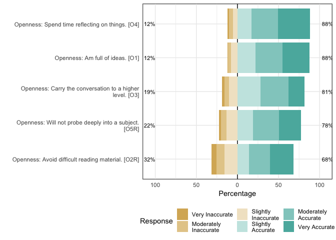

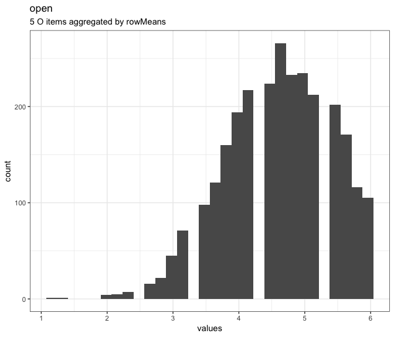

#### Reliability details

##### Reliability

##### 95% Confidence Interval

| lower | estimate | upper |
| --- | --- | --- |
| 0.5769 | 0.6002 | 0.6234 |

| raw_alpha | std.alpha | G6(smc) | average_r | S/N | ase | mean | sd | median_r |
| --- | --- | --- | --- | --- | --- | --- | --- | --- |
| 0.6002 | 0.6073 | 0.5681 | 0.2362 | 1.546 | 0.01186 | 4.587 | 0.8084 | 0.2261 |

##### Reliability if an item is dropped:

|  | raw_alpha | std.alpha | G6(smc) | average_r | S/N | alpha se | var.r | med.r |
| --- | --- | --- | --- | --- | --- | --- | --- | --- |
| **O1** | 0.5316 | 0.5341 | 0.4762 | 0.2227 | 1.146 | 0.01428 | 0.009206 | 0.2278 |
| **O2R** | 0.5672 | 0.5701 | 0.5103 | 0.249 | 1.326 | 0.01334 | 0.007597 | 0.2164 |
| **O3** | 0.4974 | 0.5006 | 0.4418 | 0.2004 | 1.002 | 0.01527 | 0.007096 | 0.1961 |
| **O4** | 0.6115 | 0.6208 | 0.5603 | 0.2904 | 1.637 | 0.0119 | 0.00437 | 0.2854 |
| **O5R** | 0.5117 | 0.528 | 0.4738 | 0.2185 | 1.118 | 0.01504 | 0.01154 | 0.2039 |

##### Item statistics

|  | n | raw.r | std.r | r.cor | r.drop | mean | sd |
| --- | --- | --- | --- | --- | --- | --- | --- |
| **O1** | 2778 | 0.6151 | 0.6496 | 0.5156 | 0.3907 | 4.816 | 1.13 |
| **O2R** | 2800 | 0.654 | 0.5991 | 0.4298 | 0.3321 | 4.287 | 1.565 |
| **O3** | 2772 | 0.6747 | 0.6926 | 0.5911 | 0.4505 | 4.438 | 1.221 |
| **O4** | 2786 | 0.4979 | 0.5193 | 0.2903 | 0.2179 | 4.892 | 1.221 |
| **O5R** | 2780 | 0.6704 | 0.6577 | 0.5237 | 0.4162 | 4.51 | 1.328 |

##### Non missing response frequency for each item

|  | 1 | 2 | 3 | 4 | 5 | 6 | miss |
| --- | --- | --- | --- | --- | --- | --- | --- |
| **O1** | 0.007919 | 0.03708 | 0.07559 | 0.2181 | 0.333 | 0.3283 | 0.007857 |
| **O2R** | 0.06393 | 0.09857 | 0.1554 | 0.1386 | 0.2561 | 0.2875 | 0 |
| **O3** | 0.02742 | 0.05231 | 0.1053 | 0.2796 | 0.3402 | 0.1952 | 0.01 |
| **O4** | 0.01974 | 0.04487 | 0.05528 | 0.1726 | 0.3184 | 0.3891 | 0.005 |
| **O5R** | 0.02518 | 0.06871 | 0.1309 | 0.1892 | 0.3176 | 0.2683 | 0.007143 |

#### Summary statistics

| name | label | data_type | value_labels | missing | complete | n | mean | sd | p0 | p25 | p50 | p75 | p100 | hist |
| --- | --- | --- | --- | --- | --- | --- | --- | --- | --- | --- | --- | --- | --- | --- |
| O1 | Openness: Am full of ideas. | integer | 1. Very Inaccurate, 2. Moderately Inaccurate, 3. Slightly Inaccurate, 4. Slightly Accurate, 5. Moderately Accurate, 6. Very Accurate | 22 | 2778 | 2800 | 4.82 | 1.13 | 1 | 4 | 5 | 6 | 6 | ▁▁▁▂▅▁▇▇ |
| O2R | Openness: Avoid difficult reading material. | numeric | 6. Very Inaccurate, 5. Moderately Inaccurate, 4. Slightly Inaccurate, 3. Slightly Accurate, 2. Moderately Accurate, 1. Very Accurate | 0 | 2800 | 2800 | 4.29 | 1.57 | 1 | 3 | 5 | 6 | 6 | ▂▃▁▅▃▁▇▇ |
| O3 | Openness: Carry the conversation to a higher level. | integer | 1. Very Inaccurate, 2. Moderately Inaccurate, 3. Slightly Inaccurate, 4. Slightly Accurate, 5. Moderately Accurate, 6. Very Accurate | 28 | 2772 | 2800 | 4.44 | 1.22 | 1 | 4 | 5 | 5 | 6 | ▁▁▁▂▆▁▇▅ |
| O4 | Openness: Spend time reflecting on things. | integer | 1. Very Inaccurate, 2. Moderately Inaccurate, 3. Slightly Inaccurate, 4. Slightly Accurate, 5. Moderately Accurate, 6. Very Accurate | 14 | 2786 | 2800 | 4.89 | 1.22 | 1 | 4 | 5 | 6 | 6 | ▁▁▁▁▃▁▆▇ |
| O5R | Openness: Will not probe deeply into a subject. | numeric | 6. Very Inaccurate, 5. Moderately Inaccurate, 4. Slightly Inaccurate, 3. Slightly Accurate, 2. Moderately Accurate, 1. Very Accurate | 20 | 2780 | 2800 | 4.51 | 1.33 | 1 | 4 | 5 | 6 | 6 | ▁▂▁▃▅▁▇▇ |

### Scale: agree

#### Overview

**Reliability**: Cronbach’s α [95% CI] = 0.7 [0.69;0.72].

**Missings**: 91.

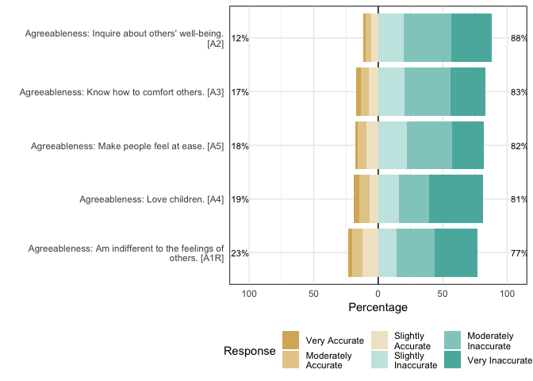

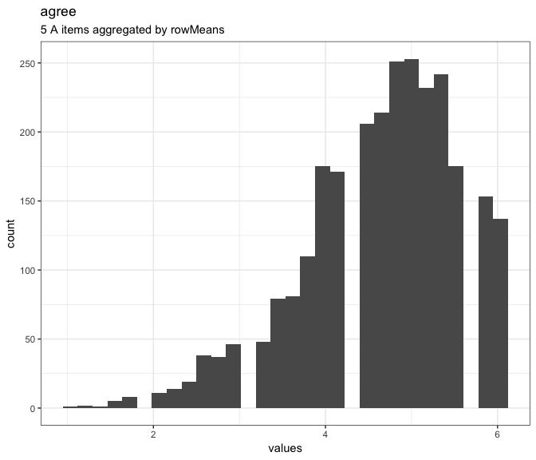

#### Reliability details

##### Reliability

##### 95% Confidence Interval

| lower | estimate | upper |
| --- | --- | --- |
| 0.6855 | 0.703 | 0.7206 |

| raw_alpha | std.alpha | G6(smc) | average_r | S/N | ase | mean | sd | median_r |
| --- | --- | --- | --- | --- | --- | --- | --- | --- |
| 0.703 | 0.713 | 0.6828 | 0.332 | 2.485 | 0.008952 | 4.652 | 0.8984 | 0.3376 |

##### Reliability if an item is dropped:

|  | raw_alpha | std.alpha | G6(smc) | average_r | S/N | alpha se | var.r | med.r |
| --- | --- | --- | --- | --- | --- | --- | --- | --- |
| **A1R** | 0.7185 | 0.7255 | 0.673 | 0.3979 | 2.643 | 0.008725 | 0.00653 | 0.376 |
| **A2** | 0.6172 | 0.6256 | 0.5795 | 0.2946 | 1.671 | 0.0119 | 0.01695 | 0.2866 |
| **A3** | 0.6003 | 0.6129 | 0.5578 | 0.2836 | 1.584 | 0.01244 | 0.009431 | 0.3219 |
| **A4** | 0.6858 | 0.6935 | 0.6498 | 0.3613 | 2.263 | 0.009825 | 0.01586 | 0.3651 |
| **A5** | 0.643 | 0.6555 | 0.6051 | 0.3224 | 1.903 | 0.01115 | 0.0126 | 0.3376 |

##### Item statistics

|  | n | raw.r | std.r | r.cor | r.drop | mean | sd |
| --- | --- | --- | --- | --- | --- | --- | --- |
| **A1R** | 2784 | 0.5807 | 0.5664 | 0.3764 | 0.3084 | 4.587 | 1.408 |
| **A2** | 2773 | 0.728 | 0.748 | 0.6665 | 0.5636 | 4.802 | 1.172 |
| **A3** | 2774 | 0.7603 | 0.7674 | 0.7092 | 0.587 | 4.604 | 1.302 |
| **A4** | 2781 | 0.6542 | 0.6307 | 0.4712 | 0.3944 | 4.7 | 1.48 |
| **A5** | 2784 | 0.6866 | 0.6992 | 0.5957 | 0.4886 | 4.56 | 1.259 |

##### Non missing response frequency for each item

|  | 1 | 2 | 3 | 4 | 5 | 6 | miss |
| --- | --- | --- | --- | --- | --- | --- | --- |
| **A1R** | 0.02945 | 0.0801 | 0.121 | 0.1444 | 0.2938 | 0.3312 | 0.005714 |
| **A2** | 0.01695 | 0.04544 | 0.05445 | 0.1994 | 0.3689 | 0.3148 | 0.009643 |
| **A3** | 0.03244 | 0.062 | 0.07462 | 0.2033 | 0.3554 | 0.2722 | 0.009286 |
| **A4** | 0.04639 | 0.07731 | 0.06652 | 0.1622 | 0.2352 | 0.4124 | 0.006786 |
| **A5** | 0.02119 | 0.06681 | 0.09124 | 0.2216 | 0.3495 | 0.2496 | 0.005714 |

#### Summary statistics

| name | label | data_type | value_labels | missing | complete | n | mean | sd | p0 | p25 | p50 | p75 | p100 | hist |
| --- | --- | --- | --- | --- | --- | --- | --- | --- | --- | --- | --- | --- | --- | --- |
| A1R | Agreeableness: Am indifferent to the feelings of others. | numeric | 6. Very Inaccurate, 5. Moderately Inaccurate, 4. Slightly Inaccurate, 3. Slightly Accurate, 2. Moderately Accurate, 1. Very Accurate | 16 | 2784 | 2800 | 4.59 | 1.41 | 1 | 4 | 5 | 6 | 6 | ▁▂▁▃▃▁▇▇ |
| A2 | Agreeableness: Inquire about others’ well-being. | integer | 1. Very Inaccurate, 2. Moderately Inaccurate, 3. Slightly Inaccurate, 4. Slightly Accurate, 5. Moderately Accurate, 6. Very Accurate | 27 | 2773 | 2800 | 4.8 | 1.17 | 1 | 4 | 5 | 6 | 6 | ▁▁▁▁▅▁▇▇ |
| A3 | Agreeableness: Know how to comfort others. | integer | 1. Very Inaccurate, 2. Moderately Inaccurate, 3. Slightly Inaccurate, 4. Slightly Accurate, 5. Moderately Accurate, 6. Very Accurate | 26 | 2774 | 2800 | 4.6 | 1.3 | 1 | 4 | 5 | 6 | 6 | ▁▂▁▂▅▁▇▆ |
| A4 | Agreeableness: Love children. | integer | 1. Very Inaccurate, 2. Moderately Inaccurate, 3. Slightly Inaccurate, 4. Slightly Accurate, 5. Moderately Accurate, 6. Very Accurate | 19 | 2781 | 2800 | 4.7 | 1.48 | 1 | 4 | 5 | 6 | 6 | ▁▂▁▁▃▁▅▇ |
| A5 | Agreeableness: Make people feel at ease. | integer | 1. Very Inaccurate, 2. Moderately Inaccurate, 3. Slightly Inaccurate, 4. Slightly Accurate, 5. Moderately Accurate, 6. Very Accurate | 16 | 2784 | 2800 | 4.56 | 1.26 | 1 | 4 | 5 | 5 | 6 | ▁▂▁▂▅▁▇▆ |

### Scale: neuro

#### Overview

**Reliability**: Cronbach’s α [95% CI] = 0.81 [0.8;0.82].

**Missings**: 106.

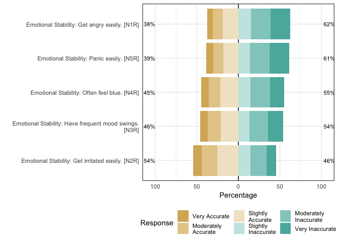

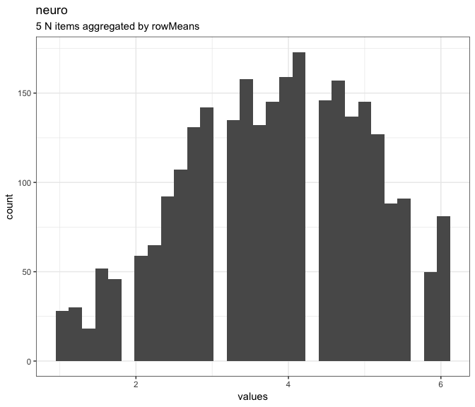

#### Reliability details

##### Reliability

##### 95% Confidence Interval

| lower | estimate | upper |
| --- | --- | --- |
| 0.803 | 0.814 | 0.825 |

| raw_alpha | std.alpha | G6(smc) | average_r | S/N | ase | mean | sd | median_r |
| --- | --- | --- | --- | --- | --- | --- | --- | --- |
| 0.814 | 0.8147 | 0.7991 | 0.4679 | 4.396 | 0.005607 | 3.838 | 1.196 | 0.4137 |

##### Reliability if an item is dropped:

|  | raw_alpha | std.alpha | G6(smc) | average_r | S/N | alpha se | var.r | med.r |
| --- | --- | --- | --- | --- | --- | --- | --- | --- |
| **N1R** | 0.7581 | 0.7583 | 0.711 | 0.4396 | 3.138 | 0.007474 | 0.006093 | 0.4132 |
| **N2R** | 0.7632 | 0.7634 | 0.7159 | 0.4465 | 3.226 | 0.007322 | 0.005421 | 0.4137 |
| **N3R** | 0.7553 | 0.7567 | 0.7312 | 0.4374 | 3.11 | 0.007663 | 0.01787 | 0.3946 |
| **N4R** | 0.7953 | 0.7969 | 0.7688 | 0.4952 | 3.924 | 0.006405 | 0.01817 | 0.489 |
| **N5R** | 0.8126 | 0.8128 | 0.787 | 0.5205 | 4.343 | 0.005854 | 0.01374 | 0.5344 |

##### Item statistics

|  | n | raw.r | std.r | r.cor | r.drop | mean | sd |
| --- | --- | --- | --- | --- | --- | --- | --- |
| **N1R** | 2778 | 0.8 | 0.8025 | 0.7648 | 0.6672 | 4.071 | 1.571 |
| **N2R** | 2779 | 0.7873 | 0.7917 | 0.7496 | 0.6526 | 3.492 | 1.526 |
| **N3R** | 2789 | 0.8081 | 0.806 | 0.7425 | 0.6748 | 3.783 | 1.603 |
| **N4R** | 2764 | 0.7152 | 0.7145 | 0.5985 | 0.5428 | 3.814 | 1.57 |
| **N5R** | 2771 | 0.6806 | 0.6744 | 0.5318 | 0.4865 | 4.03 | 1.619 |

##### Non missing response frequency for each item

|  | 1 | 2 | 3 | 4 | 5 | 6 | miss |
| --- | --- | --- | --- | --- | --- | --- | --- |
| **N1R** | 0.06983 | 0.1202 | 0.1854 | 0.1537 | 0.2354 | 0.2354 | 0.007857 |
| **N2R** | 0.104 | 0.1835 | 0.2551 | 0.1479 | 0.1925 | 0.1169 | 0.0075 |
| **N3R** | 0.09215 | 0.1574 | 0.2119 | 0.1309 | 0.2288 | 0.1789 | 0.003929 |
| **N4R** | 0.08973 | 0.1375 | 0.22 | 0.1451 | 0.237 | 0.1708 | 0.01286 |
| **N5R** | 0.08697 | 0.118 | 0.183 | 0.1379 | 0.2382 | 0.236 | 0.01036 |

#### Summary statistics

| name | label | data_type | value_labels | missing | complete | n | mean | sd | p0 | p25 | p50 | p75 | p100 | hist |
| --- | --- | --- | --- | --- | --- | --- | --- | --- | --- | --- | --- | --- | --- | --- |
| N1R | Emotional Stability: Get angry easily. | numeric | 6. Very Inaccurate, 5. Moderately Inaccurate, 4. Slightly Inaccurate, 3. Slightly Accurate, 2. Moderately Accurate, 1. Very Accurate | 22 | 2778 | 2800 | 4.07 | 1.57 | 1 | 3 | 4 | 5 | 6 | ▂▅▁▆▅▁▇▇ |
| N2R | Emotional Stability: Get irritated easily. | numeric | 6. Very Inaccurate, 5. Moderately Inaccurate, 4. Slightly Inaccurate, 3. Slightly Accurate, 2. Moderately Accurate, 1. Very Accurate | 21 | 2779 | 2800 | 3.49 | 1.53 | 1 | 2 | 3 | 5 | 6 | ▃▆▁▇▅▁▆▃ |
| N3R | Emotional Stability: Have frequent mood swings. | numeric | 6. Very Inaccurate, 5. Moderately Inaccurate, 4. Slightly Inaccurate, 3. Slightly Accurate, 2. Moderately Accurate, 1. Very Accurate | 11 | 2789 | 2800 | 3.78 | 1.6 | 1 | 3 | 4 | 5 | 6 | ▃▆▁▇▅▁▇▆ |
| N4R | Emotional Stability: Often feel blue. | numeric | 6. Very Inaccurate, 5. Moderately Inaccurate, 4. Slightly Inaccurate, 3. Slightly Accurate, 2. Moderately Accurate, 1. Very Accurate | 36 | 2764 | 2800 | 3.81 | 1.57 | 1 | 3 | 4 | 5 | 6 | ▃▅▁▇▅▁▇▆ |
| N5R | Emotional Stability: Panic easily. | numeric | 6. Very Inaccurate, 5. Moderately Inaccurate, 4. Slightly Inaccurate, 3. Slightly Accurate, 2. Moderately Accurate, 1. Very Accurate | 29 | 2771 | 2800 | 4.03 | 1.62 | 1 | 3 | 4 | 5 | 6 | ▃▃▁▆▅▁▇▇ |

## Missingness report

Among those who finished the survey. Only variables that have missings are shown.

| description | E4 | N3R | O4 | A1R | A5 | C5R | E2R | A4 | C3 | O5R | C1 | E5 | N2R | N1R | O1 | E1R | C2 | E3 | A3 | C4R | A2 | O3 | N5R | N4R | open | extra | agree | consc | neuro | … |
| --- | --- | --- | --- | --- | --- | --- | --- | --- | --- | --- | --- | --- | --- | --- | --- | --- | --- | --- | --- | --- | --- | --- | --- | --- | --- | --- | --- | --- | --- | --- |
| Missings in 0 variables | 1 | 1 | 1 | 1 | 1 | 1 | 1 | 1 | 1 | 1 | 1 | 1 | 1 | 1 | 1 | 1 | 1 | 1 | 1 | 1 | 1 | 1 | 1 | 1 | 1 | 1 | 1 | 1 | 1 | … |
| Missings per variable | 9 | 11 | 14 | 16 | 16 | 16 | 16 | 19 | 20 | 20 | 21 | 21 | 21 | 22 | 22 | 23 | 24 | 25 | 26 | 26 | 27 | 28 | 29 | 36 | 74 | 87 | 91 | 93 | 106 | … |
| Missings in 1 variables | 1 | 1 | 1 | 1 | 1 | 1 | 1 | 1 | 1 | 1 | 1 | 1 | 1 | 1 | 1 | 1 | 1 | 1 | 1 | 1 | 1 | 1 | 1 | 1 | 1 | 1 | 1 | 1 | 1 | … |
| 99 other, less frequent patterns | 95 | 92 | 93 | 90 | 93 | 93 | 92 | 87 | 87 | 88 | 93 | 94 | 92 | 89 | 90 | 91 | 86 | 87 | 87 | 87 | 87 | 83 | 86 | 87 | 65 | 68 | 59 | 61 | 61 | … |

### Codebook table

| name | label | data_type | value_labels | scale_item_names | missing | complete | n | mean | sd | p0 | p25 | p50 | p75 | p100 | hist |
| --- | --- | --- | --- | --- | --- | --- | --- | --- | --- | --- | --- | --- | --- | --- | --- |
| A1R | Agreeableness: Am indifferent to the feelings of others. | numeric | 6. Very Inaccurate, 5. Moderately Inaccurate, 4. Slightly Inaccurate, 3. Slightly Accurate, 2. Moderately Accurate, 1. Very Accurate | NA | 16 | 2784 | 2800 | 4.59 | 1.41 | 1 | 4 | 5 | 6 | 6 | ▁▂▁▃▃▁▇▇ |
| A2 | Agreeableness: Inquire about others’ well-being. | integer | 1. Very Inaccurate, 2. Moderately Inaccurate, 3. Slightly Inaccurate, 4. Slightly Accurate, 5. Moderately Accurate, 6. Very Accurate | NA | 27 | 2773 | 2800 | 4.8 | 1.17 | 1 | 4 | 5 | 6 | 6 | ▁▁▁▁▅▁▇▇ |
| A3 | Agreeableness: Know how to comfort others. | integer | 1. Very Inaccurate, 2. Moderately Inaccurate, 3. Slightly Inaccurate, 4. Slightly Accurate, 5. Moderately Accurate, 6. Very Accurate | NA | 26 | 2774 | 2800 | 4.6 | 1.3 | 1 | 4 | 5 | 6 | 6 | ▁▂▁▂▅▁▇▆ |
| A4 | Agreeableness: Love children. | integer | 1. Very Inaccurate, 2. Moderately Inaccurate, 3. Slightly Inaccurate, 4. Slightly Accurate, 5. Moderately Accurate, 6. Very Accurate | NA | 19 | 2781 | 2800 | 4.7 | 1.48 | 1 | 4 | 5 | 6 | 6 | ▁▂▁▁▃▁▅▇ |
| A5 | Agreeableness: Make people feel at ease. | integer | 1. Very Inaccurate, 2. Moderately Inaccurate, 3. Slightly Inaccurate, 4. Slightly Accurate, 5. Moderately Accurate, 6. Very Accurate | NA | 16 | 2784 | 2800 | 4.56 | 1.26 | 1 | 4 | 5 | 5 | 6 | ▁▂▁▂▅▁▇▆ |
| C1 | Conscientiousness: Am exacting in my work. | integer | 1. Very Inaccurate, 2. Moderately Inaccurate, 3. Slightly Inaccurate, 4. Slightly Accurate, 5. Moderately Accurate, 6. Very Accurate | NA | 21 | 2779 | 2800 | 4.5 | 1.24 | 1 | 4 | 5 | 5 | 6 | ▁▁▁▂▅▁▇▅ |
| C2 | Conscientiousness: Continue until everything is perfect. | integer | 1. Very Inaccurate, 2. Moderately Inaccurate, 3. Slightly Inaccurate, 4. Slightly Accurate, 5. Moderately Accurate, 6. Very Accurate | NA | 24 | 2776 | 2800 | 4.37 | 1.32 | 1 | 4 | 5 | 5 | 6 | ▁▂▁▂▆▁▇▅ |
| C3 | Conscientiousness: Do things according to a plan. | integer | 1. Very Inaccurate, 2. Moderately Inaccurate, 3. Slightly Inaccurate, 4. Slightly Accurate, 5. Moderately Accurate, 6. Very Accurate | NA | 20 | 2780 | 2800 | 4.3 | 1.29 | 1 | 4 | 5 | 5 | 6 | ▁▂▁▂▆▁▇▅ |
| C4R | Conscientiousness: Do things in a half-way manner. | numeric | 6. Very Inaccurate, 5. Moderately Inaccurate, 4. Slightly Inaccurate, 3. Slightly Accurate, 2. Moderately Accurate, 1. Very Accurate | NA | 26 | 2774 | 2800 | 4.45 | 1.38 | 1 | 3 | 5 | 6 | 6 | ▁▂▁▅▅▁▇▇ |
| C5R | Conscientiousness: Waste my time. | numeric | 6. Very Inaccurate, 5. Moderately Inaccurate, 4. Slightly Inaccurate, 3. Slightly Accurate, 2. Moderately Accurate, 1. Very Accurate | NA | 16 | 2784 | 2800 | 3.7 | 1.63 | 1 | 2 | 4 | 5 | 6 | ▃▆▁▇▅▁▇▆ |
| E1R | Extraversion: Don’t talk a lot. | numeric | 6. Very Inaccurate, 5. Moderately Inaccurate, 4. Slightly Inaccurate, 3. Slightly Accurate, 2. Moderately Accurate, 1. Very Accurate | NA | 23 | 2777 | 2800 | 4.03 | 1.63 | 1 | 3 | 4 | 5 | 6 | ▃▅▁▆▅▁▇▇ |
| E2R | Extraversion: Find it difficult to approach others. | numeric | 6. Very Inaccurate, 5. Moderately Inaccurate, 4. Slightly Inaccurate, 3. Slightly Accurate, 2. Moderately Accurate, 1. Very Accurate | NA | 16 | 2784 | 2800 | 3.86 | 1.61 | 1 | 3 | 4 | 5 | 6 | ▃▅▁▇▅▁▇▆ |
| E3 | Extraversion: Know how to captivate people. | integer | 1. Very Inaccurate, 2. Moderately Inaccurate, 3. Slightly Inaccurate, 4. Slightly Accurate, 5. Moderately Accurate, 6. Very Accurate | NA | 25 | 2775 | 2800 | 4 | 1.35 | 1 | 3 | 4 | 5 | 6 | ▂▃▁▃▇▁▇▃ |
| E4 | Extraversion: Make friends easily. | integer | 1. Very Inaccurate, 2. Moderately Inaccurate, 3. Slightly Inaccurate, 4. Slightly Accurate, 5. Moderately Accurate, 6. Very Accurate | NA | 9 | 2791 | 2800 | 4.42 | 1.46 | 1 | 4 | 5 | 6 | 6 | ▁▂▁▂▃▁▇▆ |
| E5 | Extraversion: Take charge. | integer | 1. Very Inaccurate, 2. Moderately Inaccurate, 3. Slightly Inaccurate, 4. Slightly Accurate, 5. Moderately Accurate, 6. Very Accurate | NA | 21 | 2779 | 2800 | 4.42 | 1.33 | 1 | 4 | 5 | 5 | 6 | ▁▂▁▂▅▁▇▅ |
| N1R | Emotional Stability: Get angry easily. | numeric | 6. Very Inaccurate, 5. Moderately Inaccurate, 4. Slightly Inaccurate, 3. Slightly Accurate, 2. Moderately Accurate, 1. Very Accurate | NA | 22 | 2778 | 2800 | 4.07 | 1.57 | 1 | 3 | 4 | 5 | 6 | ▂▅▁▆▅▁▇▇ |
| N2R | Emotional Stability: Get irritated easily. | numeric | 6. Very Inaccurate, 5. Moderately Inaccurate, 4. Slightly Inaccurate, 3. Slightly Accurate, 2. Moderately Accurate, 1. Very Accurate | NA | 21 | 2779 | 2800 | 3.49 | 1.53 | 1 | 2 | 3 | 5 | 6 | ▃▆▁▇▅▁▆▃ |
| N3R | Emotional Stability: Have frequent mood swings. | numeric | 6. Very Inaccurate, 5. Moderately Inaccurate, 4. Slightly Inaccurate, 3. Slightly Accurate, 2. Moderately Accurate, 1. Very Accurate | NA | 11 | 2789 | 2800 | 3.78 | 1.6 | 1 | 3 | 4 | 5 | 6 | ▃▆▁▇▅▁▇▆ |
| N4R | Emotional Stability: Often feel blue. | numeric | 6. Very Inaccurate, 5. Moderately Inaccurate, 4. Slightly Inaccurate, 3. Slightly Accurate, 2. Moderately Accurate, 1. Very Accurate | NA | 36 | 2764 | 2800 | 3.81 | 1.57 | 1 | 3 | 4 | 5 | 6 | ▃▅▁▇▅▁▇▆ |
| N5R | Emotional Stability: Panic easily. | numeric | 6. Very Inaccurate, 5. Moderately Inaccurate, 4. Slightly Inaccurate, 3. Slightly Accurate, 2. Moderately Accurate, 1. Very Accurate | NA | 29 | 2771 | 2800 | 4.03 | 1.62 | 1 | 3 | 4 | 5 | 6 | ▃▃▁▆▅▁▇▇ |
| O1 | Openness: Am full of ideas. | integer | 1. Very Inaccurate, 2. Moderately Inaccurate, 3. Slightly Inaccurate, 4. Slightly Accurate, 5. Moderately Accurate, 6. Very Accurate | NA | 22 | 2778 | 2800 | 4.82 | 1.13 | 1 | 4 | 5 | 6 | 6 | ▁▁▁▂▅▁▇▇ |
| O2R | Openness: Avoid difficult reading material. | numeric | 6. Very Inaccurate, 5. Moderately Inaccurate, 4. Slightly Inaccurate, 3. Slightly Accurate, 2. Moderately Accurate, 1. Very Accurate | NA | 0 | 2800 | 2800 | 4.29 | 1.57 | 1 | 3 | 5 | 6 | 6 | ▂▃▁▅▃▁▇▇ |
| O3 | Openness: Carry the conversation to a higher level. | integer | 1. Very Inaccurate, 2. Moderately Inaccurate, 3. Slightly Inaccurate, 4. Slightly Accurate, 5. Moderately Accurate, 6. Very Accurate | NA | 28 | 2772 | 2800 | 4.44 | 1.22 | 1 | 4 | 5 | 5 | 6 | ▁▁▁▂▆▁▇▅ |
| O4 | Openness: Spend time reflecting on things. | integer | 1. Very Inaccurate, 2. Moderately Inaccurate, 3. Slightly Inaccurate, 4. Slightly Accurate, 5. Moderately Accurate, 6. Very Accurate | NA | 14 | 2786 | 2800 | 4.89 | 1.22 | 1 | 4 | 5 | 6 | 6 | ▁▁▁▁▃▁▆▇ |
| O5R | Openness: Will not probe deeply into a subject. | numeric | 6. Very Inaccurate, 5. Moderately Inaccurate, 4. Slightly Inaccurate, 3. Slightly Accurate, 2. Moderately Accurate, 1. Very Accurate | NA | 20 | 2780 | 2800 | 4.51 | 1.33 | 1 | 4 | 5 | 6 | 6 | ▁▂▁▃▅▁▇▇ |
| gender | Self-reported gender | numeric | 1. male, 2. female | NA | 0 | 2800 | 2800 | 1.67 | 0.47 | 1 | 1 | 2 | 2 | 2 | ▃▁▁▁▁▁▁▇ |
| education | Highest degree | numeric | 1. in high school, 2. finished high school, 3. some college, 4. college graduate, 5. graduate degree | NA | 223 | 2577 | 2800 | 3.19 | 1.11 | 1 | 3 | 3 | 4 | 5 | ▂▂▁▇▁▂▁▃ |
| age | age in years | integer | NA | NA | 0 | 2800 | 2800 | 28.78 | 11.13 | 3 | 20 | 26 | 35 | 86 | ▁▇▆▃▂▁▁▁ |
| consc | 5 C items aggregated by rowMeans | numeric | NA | C1, C2, C3, C4R, C5R | 93 | 2707 | 2800 | 4.26 | 0.95 | 1 | 3.6 | 4.4 | 5 | 6 | ▁▁▂▅▇▇▇▅ |
| extra | 5 E items aggregated by rowMeans | numeric | NA | E1R, E2R, E3, E4, E5 | 87 | 2713 | 2800 | 4.14 | 1.06 | 1 | 3.4 | 4.2 | 5 | 6 | ▁▁▃▅▇▇▇▆ |
| open | 5 O items aggregated by rowMeans | numeric | NA | O1, O2R, O3, O4, O5R | 74 | 2726 | 2800 | 4.59 | 0.81 | 1.2 | 4 | 4.6 | 5.2 | 6 | ▁▁▁▂▇▇▇▅ |
| agree | 5 A items aggregated by rowMeans | numeric | NA | A1R, A2, A3, A4, A5 | 91 | 2709 | 2800 | 4.64 | 0.9 | 1 | 4.2 | 4.8 | 5.4 | 6 | ▁▁▁▂▃▆▇▇ |
| neuro | 5 N items aggregated by rowMeans | numeric | NA | N1R, N2R, N3R, N4R, N5R | 106 | 2694 | 2800 | 3.84 | 1.19 | 1 | 3 | 4 | 4.8 | 6 | ▂▃▆▇▇▇▇▅ |